# assignment3

```python
import torch
import torch.nn as nn
import math
import os
import cv2
import numpy as np
from torch.utils.data import Dataset
from torch.utils.data import DataLoader
from torchvision import transforms
import pandas as pd
import time
from torch.utils.tensorboard import SummaryWriter
from tqdm import tqdm
```

```python
## Helper Functions

import matplotlib.pyplot as plt
import seaborn as sns
from sklearn.metrics import confusion_matrix
import numpy as np
import torch
import random

def plot_training_progress(train_loss, val_loss, valid_acc):
    """ Plots training metrics side-by-side """
    plt.figure(figsize=(12, 5))

    # Left subplot: Loss
    plt.subplot(1, 2, 1)
    plt.plot(train_loss, label='Train Loss', marker='o')
    plt.plot(val_loss, label='Valid Loss', marker='o')
    plt.title('Loss Progression')
    plt.xlabel('Epoch')
    plt.ylabel('Loss')
    plt.legend()
    plt.grid(True)

    # Right subplot: Accuracy
    plt.subplot(1, 2, 2)
    plt.plot(valid_acc, label='Valid Accuracy', color='green', marker='s')
    plt.title('Validation Accuracy')
    plt.xlabel('Epoch')
    plt.ylabel('Accuracy (%)')
    plt.legend()
    plt.grid(True)

    plt.tight_layout()
    plt.savefig('training_progress.png')
    plt.show()


@torch.no_grad()
def generate_diagnostics(model, eval_loader, device, class_names=['person', 'robot'],
                         num_samples=5, forced_indices=None):
    """
    Generates a confusion matrix and displays a mix of correct and wrong predictions,
    including the original image filename for easier error analysis.
    """
    model.eval()
    all_preds = []
    all_labels = []

    # Access the underlying dataset to retrieve filenames
    dataset = eval_loader.dataset

    # Store: (image_tensor, true_lbl, pred_lbl, global_idx, filename)
    all_correct_samples = []
    all_wrong_samples = []

    global_idx = 0
    for images, labels in eval_loader:
        images_dev = images.to(device)
        outputs = model(images_dev)
        preds = torch.argmax(outputs, dim=1).cpu().numpy()
        labels_np = labels.numpy()

        all_preds.extend(preds)
        all_labels.extend(labels_np)

        for idx in range(len(labels_np)):
            # Get filename from the dataset
            # Note: works for ImageFolder; uses dataset.samples[global_idx]
            img_path = dataset.samples[global_idx][0]
            filename = os.path.basename(img_path)

            sample = (images[idx].cpu(), labels_np[idx], preds[idx], global_idx, filename)

            if labels_np[idx] == preds[idx]:
                all_correct_samples.append(sample)
            else:
                all_wrong_samples.append(sample)
            global_idx += 1

    # --- 1. SELECTION LOGIC ---
    def get_mixed_samples(samples_list, n_samples):
        grouped = {i: [] for i in range(len(class_names))}
        for s in samples_list: grouped[s[1]].append(s)
        for i in range(len(class_names)): random.shuffle(grouped[i])

        selected = []
        while len(selected) < n_samples:
            added = False
            for i in range(len(class_names)):
                if len(selected) >= n_samples: break
                if grouped[i]:
                    selected.append(grouped[i].pop(0))
                    added = True
            if not added: break
        random.shuffle(selected)
        return selected

    if forced_indices:
        all_samples = all_correct_samples + all_wrong_samples
        forced = [s for s in all_samples if s[3] in forced_indices]
        final_correct = [s for s in forced if s[1] == s[2]]
        final_wrong = [s for s in forced if s[1] != s[2]]
    else:
        final_correct = get_mixed_samples(all_correct_samples, num_samples)
        final_wrong = get_mixed_samples(all_wrong_samples, num_samples)

    # --- 2. PLOT CONFUSION MATRIX ---
    cm = confusion_matrix(all_labels, all_preds)
    plt.figure(figsize=(6, 5))
    sns.heatmap(cm, annot=True, fmt='d', cmap='Blues',
                xticklabels=class_names, yticklabels=class_names)
    plt.title('Confusion Matrix')
    plt.ylabel('True Category'); plt.xlabel('Predicted Category')
    plt.tight_layout(); plt.show()

    # --- 3. PLOT IMAGE SAMPLES ---
    def imshow_tensor(tensor_img, ax):
        mean, std = np.array([0.485, 0.456, 0.406]), np.array([0.229, 0.224, 0.225])
        np_img = tensor_img.numpy().transpose((1, 2, 0))
        np_img = np.clip(std * np_img + mean, 0, 1)
        ax.imshow(np_img); ax.axis('off')

    fig, axes = plt.subplots(2, num_samples, figsize=(4 * num_samples, 7), squeeze=False)
    fig.suptitle('Model Analysis: Filenames included for error verification', fontsize=16)

    for i in range(num_samples):
        # Correct Row
        if i < len(final_correct):
            img, true, pred, g_idx, fname = final_correct[i]
            imshow_tensor(img, axes[0, i])
            axes[0, i].set_title(f"Idx: {g_idx}\nFile: {fname}\nTrue/Pred: {class_names[true]}")
        else: axes[0, i].axis('off')

        # Wrong Row
        if i < len(final_wrong):
            img, true, pred, g_idx, fname = final_wrong[i]
            imshow_tensor(img, axes[1, i])
            axes[1, i].set_title(f"Idx: {g_idx}\nFile: {fname}\nTrue: {class_names[true]}\nPred: {class_names[pred]}", color='red')
        else: axes[1, i].axis('off')

    plt.tight_layout()
    plt.savefig('model_predictions_analysis.png')
    plt.show()
```

```python
def train_epoch(model, train_loader, optimizer, criterion, epoch, device):
    """ Training a model for one epoch """

    loss_list = []

    # Removed leave=False (defaults to True). The bar will stay on screen!
    progress_bar = tqdm(enumerate(train_loader), total=len(train_loader), leave=False)

    for i, (images, labels) in progress_bar:
        images = images.to(device)
        labels = labels.to(device)

        # Clear gradients w.r.t. parameters
        optimizer.zero_grad()

        # Forward pass to get output/logits
        outputs = model(images)

        # Calculate Loss
        loss = criterion(outputs, labels)
        loss_list.append(loss.item())

        # Getting gradients w.r.t. parameters
        loss.backward()

        # Updating parameters
        optimizer.step()

        progress_bar.set_description(f"Epoch {epoch+1} Iter {i+1}: loss {loss.item():.5f}")

    mean_loss = np.mean(loss_list)
    return mean_loss, loss_list


@torch.no_grad()
def eval_model(model, eval_loader, criterion, device):
    """ Evaluating the model for either validation or test """
    correct = 0
    total = 0
    loss_list = []

    for images, labels in eval_loader:
        images = images.to(device)
        labels = labels.to(device)

        # Forward pass only to get logits/output
        outputs = model(images)

        loss = criterion(outputs, labels)
        loss_list.append(loss.item())

        # Get predictions from the maximum value
        preds = torch.argmax(outputs, dim=1)
        correct += len( torch.where(preds==labels)[0] )
        total += len(labels)

    # Total correct predictions and loss
    accuracy = correct / total * 100
    loss = np.mean(loss_list)

    return accuracy, loss


def train_model(model, optimizer, scheduler, criterion, train_loader, valid_loader, num_epochs, device, tboard=None, start_epoch=0):
    """ Training a model for a given number of epochs with advanced augmentations """

    train_loss = []
    val_loss = []
    loss_iters = []
    valid_acc = []
    assert tboard is not None, f"Tensorboard must be provided!"

    for epoch in tqdm(range(num_epochs)):

        # validation epoch
        model.eval()  # important for dropout and batch norms
        accuracy, loss = eval_model(
                    model=model, eval_loader=valid_loader,
                    criterion=criterion, device=device
            )
        valid_acc.append(accuracy)
        val_loss.append(loss)
        tboard.add_scalar(f'Accuracy/Valid', accuracy, global_step=epoch+start_epoch)
        tboard.add_scalar(f'Loss/Valid', loss, global_step=epoch+start_epoch)

        # training epoch
        model.train()
        mean_loss, cur_loss_iters = train_epoch(
                model=model, train_loader=train_loader, optimizer=optimizer,
                criterion=criterion, epoch=epoch, device=device,
            )
        scheduler.step()
        train_loss.append(mean_loss)
        tboard.add_scalar(f'Loss/Train', mean_loss, global_step=epoch+start_epoch)

        loss_iters = loss_iters + cur_loss_iters

        if (epoch % 5 == 0 or epoch == num_epochs - 1):
            print(f"Epoch {epoch+1}/{num_epochs}")
            print(f"    Train loss: {round(mean_loss, 5)}")
            print(f"    Valid loss: {round(loss, 5)}")
            print(f"    Accuracy: {accuracy}%")
            print("\n")

    print(f"Training completed")
    return train_loss, val_loss, loss_iters, valid_acc


def smooth(f, K=5):
    """ Smoothing a function using a low-pass filter (mean) of size K """
    kernel = np.ones(K) / K
    f = np.concatenate([f[:int(K//2)], f, f[int(-K//2):]])  # to account for boundaries
    smooth_f = np.convolve(f, kernel, mode="same")
    smooth_f = smooth_f[K//2: -K//2]  # removing boundary-fixes
    return smooth_f

def count_model_params(model):
    """ Counting the number of learnable parameters in a nn.Module """
    num_params = sum(p.numel() for p in model.parameters() if p.requires_grad)
    return num_params


def save_model(model, optimizer, epoch, stats):
    """ Saving model checkpoint """

    if(not os.path.exists("models")):
        os.makedirs("models")
    savepath = f"models/checkpoint_epoch_{epoch}.pth"

    if isinstance(model.lstm, nn.LSTM):
        recurrent_impl = "lstm"
    elif isinstance(model.lstm, nn.ModuleList):
        recurrent_impl = "lstm_cells"
    else:
        recurrent_impl = type(model.lstm).__name__

    torch.save({
        'epoch': epoch,
        'model_state_dict': model.state_dict(),
        'optimizer_state_dict': optimizer.state_dict(),
        'stats': stats,
        'model_meta': {
            'class_name': model.__class__.__name__,
            'recurrent_impl': recurrent_impl,
            'num_layers': model.num_layers,
            'hidden_dim': model.hidden_dim,
        }
    }, savepath)
    return


def _convert_recurrent_state_dict(source_state_dict, target_state_dict):
    """Translate between nn.LSTM and stacked nn.LSTMCell parameter names."""

    source_keys = set(source_state_dict.keys())
    target_keys = set(target_state_dict.keys())
    converted_state_dict = dict(source_state_dict)

    source_is_lstm = any(key.startswith("lstm.weight_ih_l") for key in source_keys)
    target_is_lstm = any(key.startswith("lstm.weight_ih_l") for key in target_keys)
    source_is_cells = any(key.startswith("lstm.0.weight_ih") for key in source_keys)
    target_is_cells = any(key.startswith("lstm.0.weight_ih") for key in target_keys)

    if source_is_lstm and target_is_cells:
        num_layers = sum(1 for key in source_keys if key.startswith("lstm.weight_ih_l"))
        for layer_idx in range(num_layers):
            converted_state_dict[f"lstm.{layer_idx}.weight_ih"] = converted_state_dict.pop(f"lstm.weight_ih_l{layer_idx}")
            converted_state_dict[f"lstm.{layer_idx}.weight_hh"] = converted_state_dict.pop(f"lstm.weight_hh_l{layer_idx}")
            converted_state_dict[f"lstm.{layer_idx}.bias_ih"] = converted_state_dict.pop(f"lstm.bias_ih_l{layer_idx}")
            converted_state_dict[f"lstm.{layer_idx}.bias_hh"] = converted_state_dict.pop(f"lstm.bias_hh_l{layer_idx}")
        return converted_state_dict, "lstm", "lstm_cells"

    if source_is_cells and target_is_lstm:
        layer_indices = sorted({int(key.split(".")[1]) for key in source_keys if key.startswith("lstm.")})
        for layer_idx in layer_indices:
            converted_state_dict[f"lstm.weight_ih_l{layer_idx}"] = converted_state_dict.pop(f"lstm.{layer_idx}.weight_ih")
            converted_state_dict[f"lstm.weight_hh_l{layer_idx}"] = converted_state_dict.pop(f"lstm.{layer_idx}.weight_hh")
            converted_state_dict[f"lstm.bias_ih_l{layer_idx}"] = converted_state_dict.pop(f"lstm.{layer_idx}.bias_ih")
            converted_state_dict[f"lstm.bias_hh_l{layer_idx}"] = converted_state_dict.pop(f"lstm.{layer_idx}.bias_hh")
        return converted_state_dict, "lstm_cells", "lstm"

    return converted_state_dict, None, None


def load_model(model, optimizer, savepath):
    """ Loading pretrained checkpoint """

    checkpoint = torch.load(savepath, weights_only=False)
    state_dict = checkpoint['model_state_dict']

    try:
        model.load_state_dict(state_dict)
    except RuntimeError:
        converted_state_dict, source_impl, target_impl = _convert_recurrent_state_dict(
            source_state_dict=state_dict,
            target_state_dict=model.state_dict(),
        )
        if source_impl is None:
            raise
        model.load_state_dict(converted_state_dict)
        print(f"Converted checkpoint recurrent weights from {source_impl} to {target_impl}.")

    optimizer.load_state_dict(checkpoint['optimizer_state_dict'])
    epoch = checkpoint["epoch"]
    stats = checkpoint["stats"]

    return model, optimizer, epoch, stats
```

```python
class ActionClassifier(nn.Module):
    """Classifier using Conv -> AvgPooling -> Linear with Dropout."""
    def __init__(self, in_channels=128, num_classes=6, dropout_prob=0.5):
        super().__init__()
        self.classifier = nn.Sequential(
            nn.Conv2d(in_channels, in_channels, kernel_size=3, padding=1),
            nn.ReLU(),

            # 2. Global Average Pooling (Squashes the 4x4 grid down to 1x1)
            nn.AdaptiveAvgPool2d((1, 1)),

            # 3. Flatten the dimensions for the fully connected layer
            nn.Flatten(),

            # 4. Regularization to prevent overfitting
            nn.Dropout(p=dropout_prob),

            # 5. Final classification to the 6 KTH action classes
            nn.Linear(in_channels, num_classes)
        )

    def forward(self, x):
        # x expected shape: (batch_size, 128, 4, 4)
        return self.classifier(x)
```

```python
import torch
import torch.nn as nn

class LSTMScratch(nn.Module):
    # Updated defaults: 2048 input (flattened 128x4x4 from encoder), 2048 hidden (to reshape back to 128x4x4 for classifier)
    def __init__(self, input_size=128*4*4, hidden_size=128*4*4):
        super().__init__()
        self.hidden_size = hidden_size

        # Explicit weights for each gate
        # (Input + Hidden) * Output_size
        self.W_i = nn.Linear(input_size + hidden_size, hidden_size)
        self.W_f = nn.Linear(input_size + hidden_size, hidden_size)
        self.W_g = nn.Linear(input_size + hidden_size, hidden_size)
        self.W_o = nn.Linear(input_size + hidden_size, hidden_size)

    def forward(self, x, states=None):
        b_size, seq_len, _ = x.shape

        # Initialize hidden and cell states with zeros
        h_t = torch.zeros(b_size, self.hidden_size, device=x.device)
        c_t = torch.zeros(b_size, self.hidden_size, device=x.device)

        outputs = []

        for t in range(seq_len):
            x_t = x[:, t, :]
            # Combine input and hidden state into one vector for each step
            combined = torch.cat((x_t, h_t), dim=1)

            # Now compute each gate separately and clearly
            i_t = torch.sigmoid(self.W_i(combined))
            f_t = torch.sigmoid(self.W_f(combined))
            g_t = torch.tanh(self.W_g(combined))
            o_t = torch.sigmoid(self.W_o(combined))

            # Update States
            c_t = f_t * c_t + i_t * g_t
            h_t = o_t * torch.tanh(c_t)

            outputs.append(h_t)

        return torch.stack(outputs, dim=1), (h_t, c_t)

class HybridLSTMScratchModel(nn.Module):
    def __init__(self, num_classes=6):
        super().__init__()
        self.encoder = SpatialEncoder()

        # Instantiate YOUR custom LSTMScratch instead of ConvLSTMCustom
        # Defaults to 2048 input and 2048 hidden
        self.rnn = LSTMScratch()

        # The classifier takes the final reshaped state and converts it to the 6 classes
        self.classifier = ActionClassifier(in_channels=128, num_classes=num_classes)

    def forward(self, x):
        # x shape: (batch, time, channels, height, width)
        b, t, c, h, w = x.shape

        # Merge batch and time for CNN
        x_reshaped = x.view(b * t, c, h, w)
        features = self.encoder(x_reshaped) # Output: (b*t, 128, 4, 4)

        # CRITICAL DIFFERENCE from ConvLSTM: Flatten the spatial grid!
        # Standard LSTMs cannot handle 2D grids.
        # Shape becomes: (b, t, 2048)
        features = features.view(b, t, -1)

        # Pass through your LSTMScratch
        lstm_out, _ = self.rnn(features)

        # Get the last time step: shape (b, 2048)
        last_hidden = lstm_out[:, -1, :]

        # CRITICAL: Reshape the flat vector BACK into a 4x4 spatial grid
        # so the ActionClassifier (which uses Conv2d) can process it.
        # Shape becomes: (b, 128, 4, 4)
        last_hidden = last_hidden.view(b, 128, 4, 4)

        return self.classifier(last_hidden)
```

```python
class ConvLSTMCellCustom(nn.Module):
    """
    A single cell of a ConvLSTM.
    Processes spatial data (channels, height, width) through 4 explicit gate convolutions.
    """
    def __init__(self, in_channels=128, hidden_channels=128, kernel_size=3):
        super().__init__()
        self.hidden_channels = hidden_channels
        padding = kernel_size // 2

        # Defining 4 separate convolutional kernels for the 4 LSTM gates
        # Each kernel accepts the concatenation of Input and Hidden state
        self.conv_i = nn.Conv2d(in_channels + hidden_channels, hidden_channels, kernel_size, padding=padding)
        self.conv_f = nn.Conv2d(in_channels + hidden_channels, hidden_channels, kernel_size, padding=padding)
        self.conv_g = nn.Conv2d(in_channels + hidden_channels, hidden_channels, kernel_size, padding=padding)
        self.conv_o = nn.Conv2d(in_channels + hidden_channels, hidden_channels, kernel_size, padding=padding)

    def forward(self, x, states):
        h_prev, c_prev = states

        # Combine input and previous hidden state along the channel dimension
        combined = torch.cat([x, h_prev], dim=1)

        # Compute gates explicitly
        i_t = torch.sigmoid(self.conv_i(combined)) # Input Gate
        f_t = torch.sigmoid(self.conv_f(combined)) # Forget Gate
        g_t = torch.tanh(self.conv_g(combined))    # Candidate Gate
        o_t = torch.sigmoid(self.conv_o(combined)) # Output Gate

        # Update Cell State and Hidden State
        c_next = f_t * c_prev + i_t * g_t
        h_next = o_t * torch.tanh(c_next)

        return h_next, c_next

class ConvLSTMCustom(nn.Module):
    """
    The full ConvLSTM model that iterates over a sequence of images.
    """
    def __init__(self, in_channels=128, hidden_channels=128, kernel_size=3):
        super().__init__()
        self.cell = ConvLSTMCellCustom(in_channels, hidden_channels, kernel_size)
        self.hidden_channels = hidden_channels

    def forward(self, x):
        # x shape: (batch, time, channels, height, width)
        b, t, c, h, w = x.shape

        # Initialize hidden and cell states with zeros
        h_t = torch.zeros(b, self.hidden_channels, h, w, device=x.device)
        c_t = torch.zeros(b, self.hidden_channels, h, w, device=x.device)

        outputs = []
        for i in range(t):
            h_t, c_t = self.cell(x[:, i, ...], (h_t, c_t))
            outputs.append(h_t)

        # Stack output frames along the time dimension
        return torch.stack(outputs, dim=1)

class HybridConvLSTMModel(nn.Module):
    def __init__(self, num_classes=6):
        super().__init__()
        self.encoder = SpatialEncoder()

        # The LSTM only cares about feature dimensions
        self.rnn = ConvLSTMCustom(in_channels=128, hidden_channels=128)

        # The classifier takes the final state and converts it to the 6 classes
        self.classifier = ActionClassifier(in_channels=128, num_classes=num_classes)

    def forward(self, x):
        # x expected shape: (batch, time, channels, height, width)
        b, t, c, h, w = x.shape

        # 1. Merge batch and time so the 2D CNN can process all frames
        x_reshaped = x.view(b * t, c, h, w)
        features = self.encoder(x_reshaped) # Output shape: (b*t, 128, 4, 4)

        # 2. Separate batch and time again for the Recurrent module
        # CRITICAL: We keep the 4x4 spatial grid intact because ConvLSTM needs it!
        features = features.view(b, t, 128, 4, 4)

        # 3. Pass the sequence through the ConvLSTM
        # rnn_out shape: (b, t, 128, 4, 4)
        rnn_out = self.rnn(features)

        # 4. Extract the output from the very last time step
        # Shape becomes: (b, 128, 4, 4)
        last_hidden = rnn_out[:, -1, ...]

        # 5. Classify the final aggregated memory
        return self.classifier(last_hidden)
```

#### Simple comparision

The main difference between the ConvLSTM and regural LSTM, is the way the gates are handles the LSTM gates are handled via a linear layer, while ConvLSTM is handled using Convulotional layer ... common sense.

The Fundamental Difference: ConnectivityStandard LSTM (Fully Connected): Treats the input as a "bag of features" (a 1D vector). When it calculates gates, it multiplies every input feature by every weight. It destroys the spatial grid of the image, meaning it has no inherent sense that pixel (10,10) is neighbors with pixel (10,11).ConvLSTM (Spatially Aware): Treats the input as a "spatial grid" (a 3D tensor: Channels * Height * Width). It uses convolutional kernels to calculate gates. Because a convolution only looks at a small local patch of pixels, it preserves the spatial structure of the data.

```python
class KTHDataset(Dataset):
    def __init__(self, data_path, seq_len=10, img_size=(64, 64)):
        self.data_path = data_path
        self.seq_len = seq_len
        self.img_size = img_size
        self.samples = self._prepare_samples()
        self.labels_map = {"boxing": 0, "handclapping": 1, "handwaving": 2,
                           "jogging": 3, "running": 4, "walking": 5}

    def _prepare_samples(self):
        """Scans directory and creates list of (video_path, label)"""
        samples = []
        for class_name in os.listdir(self.data_path):
            if class_name in self.labels_map:
                cls_dir = os.path.join(self.data_path, class_name)
                for video_file in os.listdir(cls_dir):
                    samples.append((os.path.join(cls_dir, video_file), self.labels_map[class_name]))
        return samples

    def __len__(self):
        return len(self.samples)

    def __getitem__(self, idx):
        video_path, label = self.samples[idx]
        cap = cv2.VideoCapture(video_path)
        frames = []

        while len(frames) < self.seq_len:
            ret, frame = cap.read()
            if not ret: # If video ends, loop or pad
                cap.set(cv2.CAP_PROP_POS_FRAMES, 0)
                continue

            # Preprocess: Grayscale and Resize
            frame = cv2.cvtColor(frame, cv2.COLOR_BGR2GRAY)
            frame = cv2.resize(frame, self.img_size)
            frame = frame / 255.0 # Normalize
            frames.append(frame)

        cap.release()

        # Convert to tensor: (Time, Channel, Height, Width)
        video_tensor = torch.tensor(np.array(frames), dtype=torch.float32).unsqueeze(1)
        return video_tensor, label
```

```python
# My Model

import torch
import torch.nn as nn

class SpatialEncoder(nn.Module):
    """CNN Encoder to extract spatial features."""
    def __init__(self, in_channels=1, out_features=128):
        super().__init__()
        self.encoder = nn.Sequential(
            nn.Conv2d(in_channels, 32, 3, padding=1), nn.BatchNorm2d(32), nn.ReLU(),
            nn.Conv2d(32, 64, 3, padding=1), nn.BatchNorm2d(64), nn.ReLU(),
            nn.MaxPool2d(2), # Output: 32x32
            nn.Conv2d(64, 128, 3, padding=1), nn.BatchNorm2d(128), nn.ReLU(),
            nn.MaxPool2d(2), # Output: 16x16
            nn.Conv2d(128, out_features, 3, padding=1), nn.ReLU(),
            nn.AdaptiveAvgPool2d((4, 4)) # Spatial preservation before flattening
        )
    def forward(self, x): return self.encoder(x)

class ActionClassifier(nn.Module):
    """Classifier using Conv -> AvgPooling -> Linear with Dropout."""
    def __init__(self, in_channels, num_classes=6, dropout_prob=0.5):
        super().__init__()
        self.classifier = nn.Sequential(
            nn.Conv2d(in_channels, in_channels, 3, padding=1),
            nn.ReLU(),
            nn.AdaptiveAvgPool2d((1, 1)),
            nn.Flatten(),
            nn.Dropout(p=dropout_prob), # Added Dropout here
            nn.Linear(in_channels, num_classes)
        )
    def forward(self, x): return self.classifier(x)

class HybridVideoModel(nn.Module):
    def __init__(self, num_classes=6):
        super().__init__()
        self.encoder = SpatialEncoder()
        self.lstm = nn.LSTM(input_size=128*4*4, hidden_size=128*4*4, batch_first=True)
        self.classifier = ActionClassifier(in_channels=128)

    def forward(self, x):
        # 1. x shape: (batch, time, channels, height, width)
        b, t, c, h, w = x.shape

        # 2. Reshape for the CNN Encoder
        x_reshaped = x.view(b * t, c, h, w)

        # 3. Spatial Encoding
        features = self.encoder(x_reshaped) # (b*t, 128, 4, 4)

        # 4. Flatten for the LSTM
        features = features.view(b, t, -1) # (b, t, 2048)

        lstm_out, _ = self.lstm(features)

        # 6. Prepare for Classifier: Extract last step and reshape
        last_hidden = lstm_out[:, -1, :].view(b, 128, 4, 4)

        return self.classifier(last_hidden)
```

```python
def create_kth_splits(root_path):
    data = []
    actions = ["boxing", "handclapping", "handwaving", "jogging", "running", "walking"]

    print(os.getcwd())
    for action in actions:
        action_path = os.path.join(root_path, action)
        for video_file in os.listdir(action_path):
            if video_file.endswith(".avi"):
                # Pattern: personXX_action_...
                person_id = int(video_file.split('_')[0].replace('person', ''))
                data.append({
                    "path": os.path.join(action_path, video_file),
                    "action": action,
                    "person": person_id
                })

    df = pd.DataFrame(data)
    # KTH standard: Persons 1-16 for training, 17-25 for validation
    train_df = df[df['person'] <= 16]
    val_df = df[df['person'] > 16]

    train_df.to_csv("train.csv", index=False)
    val_df.to_csv("val.csv", index=False)
    print(f"Split complete. Train: {len(train_df)}, Val: {len(val_df)}")

create_kth_splits('./kth_actions')
```

```
/home/user/ghietha1/Lab-Vision-Systems/assignment3
Split complete. Train: 383, Val: 216
```

```python
class KTHDataset(Dataset):
    def __init__(self, index_file, seq_len=10):
        self.df = pd.read_csv(index_file)
        self.seq_len = seq_len
        self.label_map = {action: i for i, action in enumerate(self.df['action'].unique())}
        self.transform = transforms.Compose([
            transforms.ToPILImage(),
            transforms.Resize((64, 64)),
            transforms.ToTensor(),
            transforms.Normalize(mean=[0.5], std=[0.5])
        ])

    def __len__(self): return len(self.df)

    def __getitem__(self, idx):
        path, action = self.df.iloc[idx][['path', 'action']]
        cap = cv2.VideoCapture(path)
        frames = []
        while len(frames) < self.seq_len:
            ret, frame = cap.read()
            if not ret:
                cap.set(cv2.CAP_PROP_POS_FRAMES, 0)
                continue
            frame = cv2.cvtColor(frame, cv2.COLOR_BGR2GRAY)
            frames.append(self.transform(frame))
        cap.release()
        return torch.stack(frames), self.label_map[action]
```

```python
train_ds = KTHDataset('train.csv')
val_ds = KTHDataset('val.csv')

train_loader = DataLoader(train_ds, batch_size=8, shuffle=True, num_workers=4)
val_loader = DataLoader(val_ds, batch_size=8, shuffle=False, num_workers=4)

print("DataLoaders initialized successfully.")
```

```
DataLoaders initialized successfully.
```

```python
# Pytorch LSTM

class PyTorchLSTMCellModel(nn.Module):
    def __init__(self, num_classes=6):
        super().__init__()

        # 1. Define the Spatial Encoder
        self.encoder = SpatialEncoder(in_channels=1, out_features=128)

        # 2. Define the LSTMCell
        # 128 channels * 4 height * 4 width = 2048 flattened features
        self.hidden_size = 128 * 4 * 4
        self.lstm_cell = nn.LSTMCell(input_size=self.hidden_size, hidden_size=self.hidden_size)

        # 3. Define the Action Classifier
        self.classifier = ActionClassifier(in_channels=128, num_classes=num_classes)

    def forward(self, x):
        # x shape: (batch, time, channels, height, width)
        b, t, c, h, w = x.shape

        # Merge batch and time dimensions so the CNN can process all frames
        x_reshaped = x.view(b * t, c, h, w)
        features = self.encoder(x_reshaped) # Output shape: (b*t, 128, 4, 4)

        # Flatten the spatial dimensions into a single vector per time step
        # Shape becomes: (batch, time, 2048)
        features = features.view(b, t, -1)

        # Initialize hidden state (h_t) and cell state (c_t) with zeros
        h_t = torch.zeros(b, self.hidden_size, device=x.device)
        c_t = torch.zeros(b, self.hidden_size, device=x.device)

        # Manually iterate over the time dimension
        for time_step in range(t):
            # Pass the current frame and previous states
            h_t, c_t = self.lstm_cell(features[:, time_step, :], (h_t, c_t))

        # h_t is currently a flat vector of shape (batch, 2048).
        # We must reshape it back into a 3D volume for the ActionClassifier.
        last_hidden = h_t.view(b, 128, 4, 4)

        # Pass the spatial grid directly into the classifier
        return self.classifier(last_hidden)
```

```python
# PyTorch GRU model (using nn.GRUCell)

class PyTorchGRUCellModel(nn.Module):
    def __init__(self, num_classes=6):
        super().__init__()

        # 1. Define the Spatial Encoder
        self.encoder = SpatialEncoder(in_channels=1, out_features=128)

        # 2. Define the GRUCell
        # 128 channels * 4 height * 4 width = 2048 flattened features
        self.hidden_size = 128 * 4 * 4
        self.gru_cell = nn.GRUCell(input_size=self.hidden_size, hidden_size=self.hidden_size)

        # 3. Define the Action Classifier
        self.classifier = ActionClassifier(in_channels=128, num_classes=num_classes)

    def forward(self, x):
        # x shape: (batch, time, channels, height, width)
        b, t, c, h, w = x.shape

        # Merge batch and time dimensions so the CNN can process all frames
        x_reshaped = x.view(b * t, c, h, w)
        features = self.encoder(x_reshaped) # Output shape: (b*t, 128, 4, 4)

        # Flatten the spatial dimensions into a single vector per time step
        # Shape becomes: (batch, time, 2048)
        features = features.view(b, t, -1)

        # Initialize the hidden state (h_t) with zeros
        h_t = torch.zeros(b, self.hidden_size, device=x.device)

        # Manually iterate over the time dimension
        for time_step in range(t):
            # Pass the current frame and the single previous hidden state
            h_t = self.gru_cell(features[:, time_step, :], h_t)

        # h_t is currently a flat vector of shape (batch, 2048).
        # We must reshape it back into a 3D volume for the ActionClassifier.
        last_hidden = h_t.view(b, 128, 4, 4)

        # Pass the spatial grid directly into the classifier
        return self.classifier(last_hidden)
```

```python
import time
from torch.utils.tensorboard import SummaryWriter

device = torch.device("cuda" if torch.cuda.is_available() else "cpu")
criterion = nn.CrossEntropyLoss()
results = []
```

```python
name = "My_own_model"
print(f"\n{'='*50}\nStarting Training for: {name}\n{'='*50}")

# 1. Instantiate and move to device
model = HybridVideoModel().to(device)

# 2. Initialize Optimizer and Scheduler
optimizer = torch.optim.Adam(model.parameters(), lr=1e-4)
scheduler = torch.optim.lr_scheduler.StepLR(optimizer, step_size=15, gamma=0.5)

# 3. Setup tracking
writer = SummaryWriter(log_dir=f"runs/{name}")
num_params = count_model_params(model)
start_train_time = time.time()

# 4. Train
train_loss, val_loss, loss_iters, valid_acc = train_model(
    model=model,
    optimizer=optimizer,
    scheduler=scheduler,
    criterion=criterion,
    train_loader=train_loader,
    valid_loader=val_loader,
    num_epochs=30,
    device=device,
    tboard=writer,
    start_epoch=0
)

writer.close()
total_train_time = time.time() - start_train_time

# 5. Calculate inference time
model.eval()
val_start = time.time()
with torch.no_grad():
    for images, _ in val_loader:
        images = images.to(device)
        _ = model(images)

val_inference_time = time.time() - val_start
inference_time_per_batch = val_inference_time / len(val_loader)

# 6. Save results
final_val_acc = valid_acc[-1] if len(valid_acc) > 0 else 0.0
results.append({
    "model_name": name,
    "params": num_params,
    "final_val_acc": final_val_acc,
    "total_train_time": total_train_time,
    "inference_time_per_batch": inference_time_per_batch
})
```

```
==================================================
Starting Training for: My_own_model
==================================================
```

```
  0%|                                                                                                                                | 0/30 [00:00<?, ?it/s]
  0%|                                                                                                                                | 0/48 [00:00<?, ?it/s]
```

```
    Train loss: 1.5626
    Valid loss: 1.79285
    Accuracy: 16.666666666666664%
```

```
  0%|                                                                                                                                | 0/48 [00:00<?, ?it/s]
  0%|                                                                                                                                | 0/48 [00:00<?, ?it/s]
  0%|                                                                                                                                | 0/48 [00:00<?, ?it/s]
  0%|                                                                                                                                | 0/48 [00:00<?, ?it/s]
  0%|                                                                                                                                | 0/48 [00:00<?, ?it/s]
```

```
    Train loss: 1.03451
    Valid loss: 1.02305
    Accuracy: 50.92592592592593%
```

```
  0%|                                                                                                                                | 0/48 [00:00<?, ?it/s]
  0%|                                                                                                                                | 0/48 [00:00<?, ?it/s]
  0%|                                                                                                                                | 0/48 [00:00<?, ?it/s]
  0%|                                                                                                                                | 0/48 [00:00<?, ?it/s]
  0%|                                                                                                                                | 0/48 [00:00<?, ?it/s]
```

```
    Train loss: 0.91692
    Valid loss: 0.90222
    Accuracy: 55.55555555555556%
```

```
  0%|                                                                                                                                | 0/48 [00:00<?, ?it/s]
  0%|                                                                                                                                | 0/48 [00:00<?, ?it/s]
  0%|                                                                                                                                | 0/48 [00:00<?, ?it/s]
  0%|                                                                                                                                | 0/48 [00:00<?, ?it/s]
  0%|                                                                                                                                | 0/48 [00:00<?, ?it/s]
```

```
    Train loss: 0.75371
    Valid loss: 0.84502
    Accuracy: 62.03703703703704%
```

```
  0%|                                                                                                                                | 0/48 [00:00<?, ?it/s]
  0%|                                                                                                                                | 0/48 [00:00<?, ?it/s]
  0%|                                                                                                                                | 0/48 [00:00<?, ?it/s]
  0%|                                                                                                                                | 0/48 [00:00<?, ?it/s]
  0%|                                                                                                                                | 0/48 [00:00<?, ?it/s]
```

```
    Train loss: 0.6443
    Valid loss: 0.79376
    Accuracy: 64.35185185185185%
```

```
  0%|                                                                                                                                | 0/48 [00:00<?, ?it/s]
  0%|                                                                                                                                | 0/48 [00:00<?, ?it/s]
  0%|                                                                                                                                | 0/48 [00:00<?, ?it/s]
  0%|                                                                                                                                | 0/48 [00:00<?, ?it/s]
  0%|                                                                                                                                | 0/48 [00:00<?, ?it/s]
```

```
    Train loss: 0.55342
    Valid loss: 0.78987
    Accuracy: 67.12962962962963%
```

```
  0%|                                                                                                                                | 0/48 [00:00<?, ?it/s]
  0%|                                                                                                                                | 0/48 [00:00<?, ?it/s]
  0%|                                                                                                                                | 0/48 [00:00<?, ?it/s]
  0%|                                                                                                                                | 0/48 [00:00<?, ?it/s]
```

```
    Train loss: 0.51386
    Valid loss: 0.82965
    Accuracy: 64.81481481481481%


Training completed
```

```
Generating visualizations for My_own_model
```

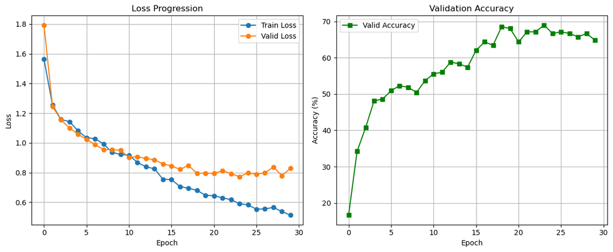

```python
# Plots
class_names = ["boxing", "handclapping", "handwaving", "jogging", "running", "walking"]

print("\nGenerating visualizations for My_own_model")
plot_training_progress(train_loss, val_loss, valid_acc)
```

my model overfits. My training loss drops, but validation loss plateaus after epoch 15, capping accuracy around 68%. The diverging plots highlight this generalization gap. To improve, I must use early stopping, increase my dropout, or add weight decay.

```python
name = "PyTorch_LSTMCell"
print(f"\n{'='*50}\nStarting Training for: {name}\n{'='*50}")

model = PyTorchLSTMCellModel().to(device)

optimizer = torch.optim.Adam(model.parameters(), lr=1e-4)
scheduler = torch.optim.lr_scheduler.StepLR(optimizer, step_size=5, gamma=0.5)

writer = SummaryWriter(log_dir=f"runs/{name}")
num_params = count_model_params(model)
start_train_time = time.time()

train_loss, val_loss, loss_iters, valid_acc = train_model(
    model=model,
    optimizer=optimizer,
    scheduler=scheduler,
    criterion=criterion,
    train_loader=train_loader,
    valid_loader=val_loader,
    num_epochs=30,
    device=device,
    tboard=writer,
    start_epoch=0
)

writer.close()
total_train_time = time.time() - start_train_time

model.eval()
val_start = time.time()
with torch.no_grad():
    for images, _ in val_loader:
        images = images.to(device)
        _ = model(images)

val_inference_time = time.time() - val_start
inference_time_per_batch = val_inference_time / len(val_loader)

final_val_acc = valid_acc[-1] if len(valid_acc) > 0 else 0.0
results.append({
    "model_name": name,
    "params": num_params,
    "final_val_acc": final_val_acc,
    "total_train_time": total_train_time,
    "inference_time_per_batch": inference_time_per_batch
})
```

```
==================================================
Starting Training for: PyTorch_LSTMCell
==================================================
```

```
  0%|                                                                                                                                | 0/30 [00:00<?, ?it/s]
  0%|                                                                                                                                | 0/48 [00:00<?, ?it/s]
```

```
    Train loss: 1.50482
    Valid loss: 1.79348
    Accuracy: 16.666666666666664%
```

```
  0%|                                                                                                                                | 0/48 [00:00<?, ?it/s]
  0%|                                                                                                                                | 0/48 [00:00<?, ?it/s]
  0%|                                                                                                                                | 0/48 [00:00<?, ?it/s]
  0%|                                                                                                                                | 0/48 [00:00<?, ?it/s]
  0%|                                                                                                                                | 0/48 [00:00<?, ?it/s]
```

```
    Train loss: 1.07357
    Valid loss: 1.07699
    Accuracy: 46.75925925925926%
```

```
  0%|                                                                                                                                | 0/48 [00:00<?, ?it/s]
  0%|                                                                                                                                | 0/48 [00:00<?, ?it/s]
  0%|                                                                                                                                | 0/48 [00:00<?, ?it/s]
  0%|                                                                                                                                | 0/48 [00:00<?, ?it/s]
  0%|                                                                                                                                | 0/48 [00:00<?, ?it/s]
```

```
    Train loss: 0.92295
    Valid loss: 0.93923
    Accuracy: 54.629629629629626%
```

```
  0%|                                                                                                                                | 0/48 [00:00<?, ?it/s]
  0%|                                                                                                                                | 0/48 [00:00<?, ?it/s]
  0%|                                                                                                                                | 0/48 [00:00<?, ?it/s]
  0%|                                                                                                                                | 0/48 [00:00<?, ?it/s]
  0%|                                                                                                                                | 0/48 [00:00<?, ?it/s]
```

```
    Train loss: 0.83267
    Valid loss: 0.90924
    Accuracy: 56.481481481481474%
```

```
  0%|                                                                                                                                | 0/48 [00:00<?, ?it/s]
  0%|                                                                                                                                | 0/48 [00:00<?, ?it/s]
  0%|                                                                                                                                | 0/48 [00:00<?, ?it/s]
  0%|                                                                                                                                | 0/48 [00:00<?, ?it/s]
  0%|                                                                                                                                | 0/48 [00:00<?, ?it/s]
```

```
    Train loss: 0.7563
    Valid loss: 0.90409
    Accuracy: 57.870370370370374%
```

```
  0%|                                                                                                                                | 0/48 [00:00<?, ?it/s]
  0%|                                                                                                                                | 0/48 [00:00<?, ?it/s]
  0%|                                                                                                                                | 0/48 [00:00<?, ?it/s]
  0%|                                                                                                                                | 0/48 [00:00<?, ?it/s]
  0%|                                                                                                                                | 0/48 [00:00<?, ?it/s]
```

```
    Train loss: 0.76824
    Valid loss: 0.89395
    Accuracy: 59.72222222222222%
```

```
  0%|                                                                                                                                | 0/48 [00:00<?, ?it/s]
  0%|                                                                                                                                | 0/48 [00:00<?, ?it/s]
  0%|                                                                                                                                | 0/48 [00:00<?, ?it/s]
  0%|                                                                                                                                | 0/48 [00:00<?, ?it/s]
```

```
    Train loss: 0.74516
    Valid loss: 0.9024
    Accuracy: 59.72222222222222%


Training completed
```

```
Generating visualizations for PyTorch_LSTMCell
```

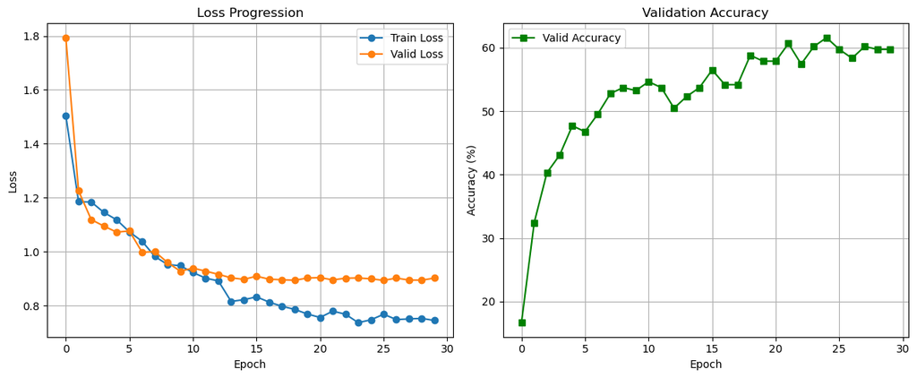

```python
# Plots
print("\nGenerating visualizations for PyTorch_LSTMCell")
plot_training_progress(train_loss, val_loss, valid_acc)
```

Unlike my previous diverging plots, my PyTorch_LSTMCell validation loss stays stable, but my accuracy is lower, peaking near 61%. This early plateau likely stems from my aggressive learning rate decay (step_size=5). To improve, I should increase the step_size to allow deeper learning before decaying.

```python
name = "PyTorch_GRUCell"
print(f"\n{'='*50}\nStarting Training for: {name}\n{'='*50}")

model = PyTorchGRUCellModel().to(device)

optimizer = torch.optim.Adam(model.parameters(), lr=1e-4)
scheduler = torch.optim.lr_scheduler.StepLR(optimizer, step_size=5, gamma=0.5)

writer = SummaryWriter(log_dir=f"runs/{name}")
num_params = count_model_params(model)
start_train_time = time.time()

train_loss, val_loss, loss_iters, valid_acc = train_model(
    model=model,
    optimizer=optimizer,
    scheduler=scheduler,
    criterion=criterion,
    train_loader=train_loader,
    valid_loader=val_loader,
    num_epochs=30,
    device=device,
    tboard=writer,
    start_epoch=0
)

writer.close()
total_train_time = time.time() - start_train_time

model.eval()
val_start = time.time()
with torch.no_grad():
    for images, _ in val_loader:
        images = images.to(device)
        _ = model(images)

val_inference_time = time.time() - val_start
inference_time_per_batch = val_inference_time / len(val_loader)

final_val_acc = valid_acc[-1] if len(valid_acc) > 0 else 0.0
results.append({
    "model_name": name,
    "params": num_params,
    "final_val_acc": final_val_acc,
    "total_train_time": total_train_time,
    "inference_time_per_batch": inference_time_per_batch
})
```

```
==================================================
Starting Training for: PyTorch_GRUCell
==================================================
```

```
  0%|                                                                                                                                | 0/30 [00:00<?, ?it/s]
  0%|                                                                                                                                | 0/48 [00:00<?, ?it/s]
```

```
    Train loss: 1.50859
    Valid loss: 1.79292
    Accuracy: 16.666666666666664%
```

```
  0%|                                                                                                                                | 0/48 [00:00<?, ?it/s]
  0%|                                                                                                                                | 0/48 [00:00<?, ?it/s]
  0%|                                                                                                                                | 0/48 [00:00<?, ?it/s]
  0%|                                                                                                                                | 0/48 [00:00<?, ?it/s]
  0%|                                                                                                                                | 0/48 [00:00<?, ?it/s]
```

```
    Train loss: 0.92831
    Valid loss: 1.02265
    Accuracy: 50.92592592592593%
```

```
  0%|                                                                                                                                | 0/48 [00:00<?, ?it/s]
  0%|                                                                                                                                | 0/48 [00:00<?, ?it/s]
  0%|                                                                                                                                | 0/48 [00:00<?, ?it/s]
  0%|                                                                                                                                | 0/48 [00:00<?, ?it/s]
  0%|                                                                                                                                | 0/48 [00:00<?, ?it/s]
```

```
    Train loss: 0.76953
    Valid loss: 0.93283
    Accuracy: 57.407407407407405%
```

```
  0%|                                                                                                                                | 0/48 [00:00<?, ?it/s]
  0%|                                                                                                                                | 0/48 [00:00<?, ?it/s]
  0%|                                                                                                                                | 0/48 [00:00<?, ?it/s]
  0%|                                                                                                                                | 0/48 [00:00<?, ?it/s]
  0%|                                                                                                                                | 0/48 [00:00<?, ?it/s]
```

```
    Train loss: 0.71716
    Valid loss: 0.9206
    Accuracy: 61.111111111111114%
```

```
  0%|                                                                                                                                | 0/48 [00:00<?, ?it/s]
  0%|                                                                                                                                | 0/48 [00:00<?, ?it/s]
  0%|                                                                                                                                | 0/48 [00:00<?, ?it/s]
  0%|                                                                                                                                | 0/48 [00:00<?, ?it/s]
  0%|                                                                                                                                | 0/48 [00:00<?, ?it/s]
```

```
    Train loss: 0.67815
    Valid loss: 0.89782
    Accuracy: 65.27777777777779%
```

```
  0%|                                                                                                                                | 0/48 [00:00<?, ?it/s]
  0%|                                                                                                                                | 0/48 [00:00<?, ?it/s]
  0%|                                                                                                                                | 0/48 [00:00<?, ?it/s]
  0%|                                                                                                                                | 0/48 [00:00<?, ?it/s]
  0%|                                                                                                                                | 0/48 [00:00<?, ?it/s]
```

```
    Train loss: 0.64484
    Valid loss: 0.89704
    Accuracy: 64.35185185185185%
```

```
  0%|                                                                                                                                | 0/48 [00:00<?, ?it/s]
  0%|                                                                                                                                | 0/48 [00:00<?, ?it/s]
  0%|                                                                                                                                | 0/48 [00:00<?, ?it/s]
  0%|                                                                                                                                | 0/48 [00:00<?, ?it/s]
```

```
    Train loss: 0.63784
    Valid loss: 0.89055
    Accuracy: 66.20370370370371%


Training completed
```

```
Generating visualizations for PyTorch_GRUCell
```

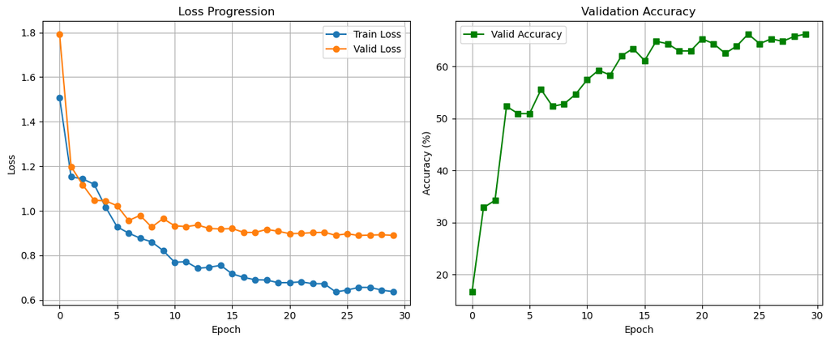

```python
# Plots
print("\nGenerating visualizations for PyTorch_GRUCell")
plot_training_progress(train_loss, val_loss, valid_acc)
```

```python
name = "Custom_LSTMScratch"
print(f"\n{'='*50}\nStarting Training for: {name}\n{'='*50}")

model = HybridLSTMScratchModel().to(device)

optimizer = torch.optim.Adam(model.parameters(), lr=1e-4)
scheduler = torch.optim.lr_scheduler.StepLR(optimizer, step_size=5, gamma=0.5)

writer = SummaryWriter(log_dir=f"runs/{name}")
num_params = count_model_params(model)
start_train_time = time.time()

train_loss, val_loss, loss_iters, valid_acc = train_model(
    model=model,
    optimizer=optimizer,
    scheduler=scheduler,
    criterion=criterion,
    train_loader=train_loader,
    valid_loader=val_loader,
    num_epochs=30,
    device=device,
    tboard=writer,
    start_epoch=0
)

writer.close()
total_train_time = time.time() - start_train_time

model.eval()
val_start = time.time()
with torch.no_grad():
    for images, _ in val_loader:
        images = images.to(device)
        _ = model(images)

val_inference_time = time.time() - val_start
inference_time_per_batch = val_inference_time / len(val_loader)

final_val_acc = valid_acc[-1] if len(valid_acc) > 0 else 0.0
results.append({
    "model_name": name,
    "params": num_params,
    "final_val_acc": final_val_acc,
    "total_train_time": total_train_time,
    "inference_time_per_batch": inference_time_per_batch
})
```

```
==================================================
Starting Training for: Custom_LSTMScratch
==================================================
```

```
  0%|                                                                                                                                | 0/30 [00:00<?, ?it/s]
  0%|                                                                                                                                | 0/48 [00:00<?, ?it/s]
```

```
    Train loss: 1.51496
    Valid loss: 1.79228
    Accuracy: 16.666666666666664%
```

```
  0%|                                                                                                                                | 0/48 [00:00<?, ?it/s]
  0%|                                                                                                                                | 0/48 [00:00<?, ?it/s]
  0%|                                                                                                                                | 0/48 [00:00<?, ?it/s]
  0%|                                                                                                                                | 0/48 [00:00<?, ?it/s]
  0%|                                                                                                                                | 0/48 [00:00<?, ?it/s]
```

```
    Train loss: 1.04218
    Valid loss: 1.03023
    Accuracy: 48.61111111111111%
```

```
  0%|                                                                                                                                | 0/48 [00:00<?, ?it/s]
  0%|                                                                                                                                | 0/48 [00:00<?, ?it/s]
  0%|                                                                                                                                | 0/48 [00:00<?, ?it/s]
  0%|                                                                                                                                | 0/48 [00:00<?, ?it/s]
  0%|                                                                                                                                | 0/48 [00:00<?, ?it/s]
```

```
    Train loss: 0.88552
    Valid loss: 0.92965
    Accuracy: 50.0%
```

```
  0%|                                                                                                                                | 0/48 [00:00<?, ?it/s]
  0%|                                                                                                                                | 0/48 [00:00<?, ?it/s]
  0%|                                                                                                                                | 0/48 [00:00<?, ?it/s]
  0%|                                                                                                                                | 0/48 [00:00<?, ?it/s]
  0%|                                                                                                                                | 0/48 [00:00<?, ?it/s]
```

```
    Train loss: 0.82798
    Valid loss: 0.87997
    Accuracy: 58.79629629629629%
```

```
  0%|                                                                                                                                | 0/48 [00:00<?, ?it/s]
  0%|                                                                                                                                | 0/48 [00:00<?, ?it/s]
  0%|                                                                                                                                | 0/48 [00:00<?, ?it/s]
  0%|                                                                                                                                | 0/48 [00:00<?, ?it/s]
  0%|                                                                                                                                | 0/48 [00:00<?, ?it/s]
```

```
    Train loss: 0.7581
    Valid loss: 0.8826
    Accuracy: 58.333333333333336%
```

```
  0%|                                                                                                                                | 0/48 [00:00<?, ?it/s]
  0%|                                                                                                                                | 0/48 [00:00<?, ?it/s]
  0%|                                                                                                                                | 0/48 [00:00<?, ?it/s]
  0%|                                                                                                                                | 0/48 [00:00<?, ?it/s]
  0%|                                                                                                                                | 0/48 [00:00<?, ?it/s]
```

```
    Train loss: 0.73476
    Valid loss: 0.87369
    Accuracy: 57.870370370370374%
```

```
  0%|                                                                                                                                | 0/48 [00:00<?, ?it/s]
  0%|                                                                                                                                | 0/48 [00:00<?, ?it/s]
  0%|                                                                                                                                | 0/48 [00:00<?, ?it/s]
  0%|                                                                                                                                | 0/48 [00:00<?, ?it/s]
```

```
    Train loss: 0.73458
    Valid loss: 0.87293
    Accuracy: 58.333333333333336%


Training completed
```

```
Generating visualizations for Custom_LSTMScratch
```

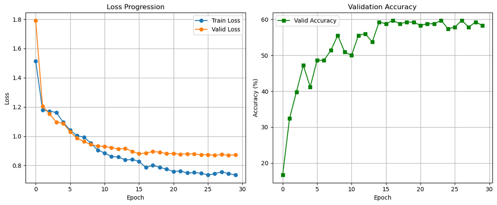

```python
# Plots
print("\nGenerating visualizations for Custom_LSTMScratch")
plot_training_progress(train_loss, val_loss, valid_acc)
```

My Custom_LSTMScratch model reaches ~60% accuracy, performing similarly to my PyTorch_LSTMCell. The loss plots show less overfitting than my very first model, but validation loss still plateaus early. To improve, I should relax my aggressive step_size=5 learning rate decay, allowing more time to learn before reducing the rate.

```python
name = "Custom_ConvLSTM"
print(f"\n{'='*50}\nStarting Training for: {name}\n{'='*50}")

model = HybridConvLSTMModel().to(device)

optimizer = torch.optim.Adam(model.parameters(), lr=1e-4)
scheduler = torch.optim.lr_scheduler.StepLR(optimizer, step_size=5, gamma=0.5)

writer = SummaryWriter(log_dir=f"runs/{name}")
num_params = count_model_params(model)
start_train_time = time.time()

train_loss, val_loss, loss_iters, valid_acc = train_model(
    model=model,
    optimizer=optimizer,
    scheduler=scheduler,
    criterion=criterion,
    train_loader=train_loader,
    valid_loader=val_loader,
    num_epochs=30,
    device=device,
    tboard=writer,
    start_epoch=0
)

writer.close()
total_train_time = time.time() - start_train_time

model.eval()
val_start = time.time()
with torch.no_grad():
    for images, _ in val_loader:
        images = images.to(device)
        _ = model(images)

val_inference_time = time.time() - val_start
inference_time_per_batch = val_inference_time / len(val_loader)

final_val_acc = valid_acc[-1] if len(valid_acc) > 0 else 0.0
results.append({
    "model_name": name,
    "params": num_params,
    "final_val_acc": final_val_acc,
    "total_train_time": total_train_time,
    "inference_time_per_batch": inference_time_per_batch
})
```

```
==================================================
Starting Training for: Custom_ConvLSTM
==================================================
```

```
  0%|                                                                                                                                | 0/30 [00:00<?, ?it/s]
  0%|                                                                                                                                | 0/48 [00:00<?, ?it/s]
```

```
    Train loss: 1.75535
    Valid loss: 1.79309
    Accuracy: 16.666666666666664%
```

```
  0%|                                                                                                                                | 0/48 [00:00<?, ?it/s]
  0%|                                                                                                                                | 0/48 [00:00<?, ?it/s]
  0%|                                                                                                                                | 0/48 [00:00<?, ?it/s]
  0%|                                                                                                                                | 0/48 [00:00<?, ?it/s]
  0%|                                                                                                                                | 0/48 [00:00<?, ?it/s]
```

```
    Train loss: 1.14466
    Valid loss: 1.14073
    Accuracy: 42.592592592592595%
```

```
  0%|                                                                                                                                | 0/48 [00:00<?, ?it/s]
  0%|                                                                                                                                | 0/48 [00:00<?, ?it/s]
  0%|                                                                                                                                | 0/48 [00:00<?, ?it/s]
  0%|                                                                                                                                | 0/48 [00:00<?, ?it/s]
  0%|                                                                                                                                | 0/48 [00:00<?, ?it/s]
```

```
    Train loss: 1.03413
    Valid loss: 1.0177
    Accuracy: 49.074074074074076%
```

```
  0%|                                                                                                                                | 0/48 [00:00<?, ?it/s]
  0%|                                                                                                                                | 0/48 [00:00<?, ?it/s]
  0%|                                                                                                                                | 0/48 [00:00<?, ?it/s]
  0%|                                                                                                                                | 0/48 [00:00<?, ?it/s]
  0%|                                                                                                                                | 0/48 [00:00<?, ?it/s]
```

```
    Train loss: 0.96296
    Valid loss: 0.9532
    Accuracy: 53.24074074074075%
```

```
  0%|                                                                                                                                | 0/48 [00:00<?, ?it/s]
  0%|                                                                                                                                | 0/48 [00:00<?, ?it/s]
  0%|                                                                                                                                | 0/48 [00:00<?, ?it/s]
  0%|                                                                                                                                | 0/48 [00:00<?, ?it/s]
  0%|                                                                                                                                | 0/48 [00:00<?, ?it/s]
```

```
    Train loss: 0.90729
    Valid loss: 0.96177
    Accuracy: 49.53703703703704%
```

```
  0%|                                                                                                                                | 0/48 [00:00<?, ?it/s]
  0%|                                                                                                                                | 0/48 [00:00<?, ?it/s]
  0%|                                                                                                                                | 0/48 [00:00<?, ?it/s]
  0%|                                                                                                                                | 0/48 [00:00<?, ?it/s]
  0%|                                                                                                                                | 0/48 [00:00<?, ?it/s]
```

```
    Train loss: 0.87984
    Valid loss: 0.93959
    Accuracy: 52.77777777777778%
```

```
  0%|                                                                                                                                | 0/48 [00:00<?, ?it/s]
  0%|                                                                                                                                | 0/48 [00:00<?, ?it/s]
  0%|                                                                                                                                | 0/48 [00:00<?, ?it/s]
  0%|                                                                                                                                | 0/48 [00:00<?, ?it/s]
```

```
    Train loss: 0.90825
    Valid loss: 0.95029
    Accuracy: 50.92592592592593%


Training completed
```

```
Generating visualizations for Custom_ConvLSTM
```

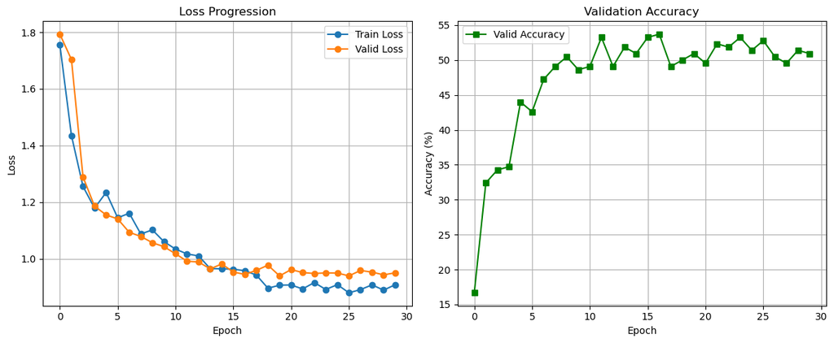

```python
# Plots
print("\nGenerating visualizations for Custom_ConvLSTM")
plot_training_progress(train_loss, val_loss, valid_acc)
```

```python
print(f"\n{'='*85}")
print(f"{'Model':<20} | {'Parameters':<12} | {'Val Acc (%)':<12} | {'Train Time (s)':<15} | {'Inf Time/Batch (s)'}")
print(f"{'-'*85}")
for res in results:
    print(f"{res['model_name']:<20} | {res['params']:<12,} | {res['final_val_acc']:<12.2f} | {res['total_train_time']:<15.1f} | {res['inference_time_per_batch']:.4f}")
print(f"{'='*85}\n")
```

```
=====================================================================================
Model                | Parameters   | Val Acc (%)  | Train Time (s)  | Inf Time/Batch (s)
-------------------------------------------------------------------------------------
My_own_model         | 33,959,878   | 64.81        | 1278.3          | 0.2243
PyTorch_LSTMCell     | 33,959,878   | 59.72        | 1741.6          | 0.2353
PyTorch_GRUCell      | 25,567,174   | 66.20        | 1503.8          | 0.2166
Custom_LSTMScratch   | 33,951,686   | 58.33        | 1859.2          | 0.2633
Custom_ConvLSTM      | 1,569,222    | 50.93        | 859.5           | 0.1857
=====================================================================================
```